# **Data Science and Machine Learning using the Titanic Dataset**

## Stage 1: Data Collection

1. Data can be obtained from various sources eg databases,files,manual entry,APIs

```python
import pandas as pd
titanic_data=pd.read_csv("C:/Users/HP/Desktop/DataScience/Data/titanic.csv")
```

## Stage 2: Data Cleaning

1. Handling missing values by either removing or imputing them
2. Removing unncessary duplicates if they exist
3. Correcting incosistent or inaccurate values if there are

### Import Packages

```python
import numpy as np
import pandas as pd
import matplotlib.pyplot as plt
import seaborn as sns
import sklearn.datasets
from sklearn.model_selection import train_test_split,GridSearchCV,cross_val_score
from sklearn.preprocessing import StandardScaler,LabelEncoder
from sklearn.ensemble import RandomForestClassifier
from sklearn.metrics import accuracy_score,classification_report,confusion_matrix
from sklearn.svm import SVC,LinearSVC
from sklearn.linear_model import LogisticRegressionCV,Lasso,LogisticRegression,Ridge
from sklearn.impute import KNNImputer
from sklearn.feature_selection import SelectFromModel,chi2,RFE,SelectKBest,f_classif,mutual_info_classif
from sklearn.neighbors import KNeighborsClassifier
from sklearn.tree import DecisionTreeClassifier

import warnings
warnings.filterwarnings("ignore")
```

## Stage 3: Exploratory Data Analysis

1. Getting to understand the structure and characteristics of the data
2. Visualize data distributions , relationships , and patterns.
3. Identify potential outliers or anomalies

## Important Notes

### Background to the Dataset

#### The RMS Titanic was a British passenger liner that sank in the North Atlantic ocean in the early morning hours of April 15th 1912, after it collided with an iceberg during its maiden voyage from Southampton to New York City. There were estimated 1308 passengers and the crew aboard the ship, and more than 500 persons died, making it one of the deadliest commercial peacetime maritime disasters in modern history,

### Purpose of the Analysis and Building of Model

1. Determine the factors that contributed to the chances of survival of people aboard the ship
2. Build a model that does well to predict the survival of passengers based off a set of data

### Data Inspection of the Titanic Dataset

#### According to this data, 891 persons were aboard the ship

#### According to this data, about 549 persons (61.6%) died and 342 (38.4%) persons survived

#### 15 features were collected which represents the columns used in the analysis

#### The titanic data upon inpection is a categorical data in which Yes Survived is represented by 1 and Did not Survive is 0

#### Codes for the Data Inspection

```python
titanic_data=pd.read_csv("C:/Users/HP/Desktop/DataScience/Data/titanic.csv")
titanic_data.head(n=7)
print(titanic_data.columns)
print(titanic_data.shape)
print((titanic_data['survived']==0).sum())
print((342/891)*100)
print(titanic_data.describe())
print(titanic_data.info())
titanic_data.head(n=7)
```

```
Index(['survived', 'pclass', 'sex', 'age', 'sibsp', 'parch', 'fare',
       'embarked', 'class', 'who', 'adult_male', 'deck', 'embark_town',
       'alive', 'alone'],
      dtype='object')
(891, 15)
549
38.38383838383838
         survived      pclass         age       sibsp       parch        fare
count  891.000000  891.000000  714.000000  891.000000  891.000000  891.000000
mean     0.383838    2.308642   29.699118    0.523008    0.381594   32.204208
std      0.486592    0.836071   14.526497    1.102743    0.806057   49.693429
min      0.000000    1.000000    0.420000    0.000000    0.000000    0.000000
25%      0.000000    2.000000   20.125000    0.000000    0.000000    7.910400
50%      0.000000    3.000000   28.000000    0.000000    0.000000   14.454200
75%      1.000000    3.000000   38.000000    1.000000    0.000000   31.000000
max      1.000000    3.000000   80.000000    8.000000    6.000000  512.329200
<class 'pandas.core.frame.DataFrame'>
RangeIndex: 891 entries, 0 to 890
Data columns (total 15 columns):
 #   Column       Non-Null Count  Dtype
---  ------       --------------  -----
 0   survived     891 non-null    int64
 1   pclass       891 non-null    int64
 2   sex          891 non-null    object
 3   age          714 non-null    float64
 4   sibsp        891 non-null    int64
 5   parch        891 non-null    int64
 6   fare         891 non-null    float64
 7   embarked     889 non-null    object
 8   class        891 non-null    object
 9   who          891 non-null    object
 10  adult_male   891 non-null    bool
 11  deck         203 non-null    object
 12  embark_town  889 non-null    object
 13  alive        891 non-null    object
 14  alone        891 non-null    bool
dtypes: bool(2), float64(2), int64(4), object(7)
memory usage: 92.4+ KB
None
```

|  | survived | pclass | sex | age | sibsp | parch | fare | embarked | class | who | adult_male | deck | embark_town | alive | alone |
| --- | --- | --- | --- | --- | --- | --- | --- | --- | --- | --- | --- | --- | --- | --- | --- |
| 0 | 0 | 3 | male | 22.0 | 1 | 0 | 7.2500 | S | Third | man | True | NaN | Southampton | no | False |
| 1 | 1 | 1 | female | 38.0 | 1 | 0 | 71.2833 | C | First | woman | False | C | Cherbourg | yes | False |
| 2 | 1 | 3 | female | 26.0 | 0 | 0 | 7.9250 | S | Third | woman | False | NaN | Southampton | yes | True |
| 3 | 1 | 1 | female | 35.0 | 1 | 0 | 53.1000 | S | First | woman | False | C | Southampton | yes | False |
| 4 | 0 | 3 | male | 35.0 | 0 | 0 | 8.0500 | S | Third | man | True | NaN | Southampton | no | True |
| 5 | 0 | 3 | male | NaN | 0 | 0 | 8.4583 | Q | Third | man | True | NaN | Queenstown | no | True |
| 6 | 0 | 1 | male | 54.0 | 0 | 0 | 51.8625 | S | First | man | True | E | Southampton | no | True |

### 1. Checking the missing values in Titanic Data

```
Missing data in age survived         0
pclass           0
sex              0
age            177
sibsp            0
parch            0
fare             0
embarked         2
class            0
who              0
adult_male       0
deck           688
embark_town      2
alive            0
alone            0
dtype: int64
```

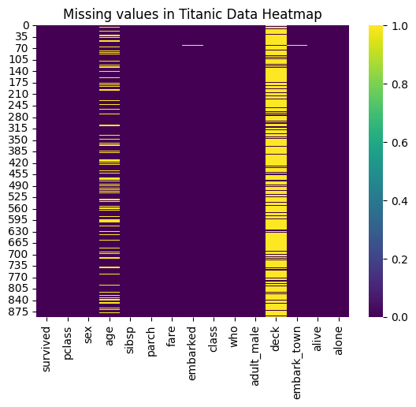

```python
print("Missing data in age",titanic_data.isnull().sum())
#sns.heatmap(titanic_data.isnull(),cmap='viridis').set_title("Missing Data Heatmap")
#titanic_data['age'].isnull().sum()

### Missing data by visualization
sns.heatmap(titanic_data.isnull(),cmap='viridis').set_title("Missing values in Titanic Data Heatmap")
```

### **Brief Report**

#### 1.Through the codes above, and before data cleaning continues, its clear there is a very substantial missing amount of data from the age column (19.8% missing data) and the deck column (77.2% missing data)

#### 2. The age simply help us know how old or young a person is , while the deck implies the part of the ship the individual was on among the 10 supposedly decks of the Titanic where people could have some fun, and could possibly impart the chances of survival.

### I won't be quick to removing the missing data, but would prefer to fix them for the following reasons:

#### 1.This will help avoid errors or biases that arise from cutting off a column which might impart on the data

#### 2. This may help preserve the original distribution and variance of the titanic data

#### 3. It helps to retain information about the missing values rather than discarding entire rows or columns.

## Stage 4: Feature Engineering

1. Create new features or transform existing ones to capture important information
2. Encode categorical variables into a format suitable for machine learning algorithms (eg one-hot encoding)

#### *Hence there is a need to check the correlation amidst the data columns, but to do this , it must be fixed*

### Options considered for fixing or handling missing data in the deck column

### Option 1 : One-Hot Encoding is a common way for fixing the categorical data.

#### This is done by creating a binary(0 or 1) column for each unique value in categorical data column eg for the deck column with A,B,C,D,E

#### Turning the categorical data in the deck column to numerical, by replacing nan with 0 and other categorical data with 1,

#### Argument for the One-Hot Encoding technique

1. Preservation of information about the presence or absence of a specific deck without introducing ordinal relationships
2. It helps to avoid unwarranted imputations, and this helps to avoid making flawed assumptions about the missing values (particularly in the light of the largr amount of data missing)

#### Identification of the categorical and numerical columns in the data

```python
print(f"The data types \n {titanic_data.dtypes} \n The categorical columns \n")
categorical_columns=titanic_data.select_dtypes(include=['object']).columns
print(f"Categorical columns: \n {categorical_columns}")

#Identifying the binary encoded columns
dummy_columns=titanic_data.columns[titanic_data.nunique()==2]
print("\n Dummy (Binary encoded) Columns \n")
print(dummy_columns)

print("\n The Numerical columns \n")
numerical_columns=titanic_data.select_dtypes(include=['number']).columns
print(f"Numerical columns: \n {numerical_columns}")
```

```
The data types
 survived         int64
pclass           int64
sex             object
age            float64
sibsp            int64
parch            int64
fare           float64
embarked        object
class           object
who             object
adult_male        bool
deck            object
embark_town     object
alive           object
alone             bool
dtype: object
 The categorical columns

Categorical columns:
 Index(['sex', 'embarked', 'class', 'who', 'deck', 'embark_town', 'alive'], dtype='object')

 Dummy (Binary encoded) Columns

Index(['survived', 'sex', 'adult_male', 'alive', 'alone'], dtype='object')

 The Numerical columns

Numerical columns:
 Index(['survived', 'pclass', 'age', 'sibsp', 'parch', 'fare'], dtype='object')
```

## Stage 5: Handling Categorical Variables

1. Convert categorical variables into a numeric format
2. Popular techniques include one-hot encoding or label encoding

#### One-hot encoding can be done using a function

```python
deck_data_only=titanic_data[['deck']].copy()
print(deck_data_only.head(n=7))
#The function to add new column comprising just numerical data to the dataframe created

def create_new_cabin(the_dataset,columnname):
    #If null, turn to 0 else turn to 1
    def not_a_number(x):
        if isinstance(x,type(np.nan)):
            return 0
        else:
            return 1
        #Apply the function on all values of the pandas series
    the_dataset[columnname]=the_dataset['deck'].apply(not_a_number)



#Here we apply the function to the deck column of our dataset
create_new_cabin(deck_data_only,'new_deck')
deck_data_only
deck_data_only[['new_deck']]
```

```
  deck
0  NaN
1    C
2  NaN
3    C
4  NaN
5  NaN
6    E
```

|  | new_deck |
| --- | --- |
| 0 | 0 |
| 1 | 1 |
| 2 | 0 |
| 3 | 1 |
| 4 | 0 |
| ... | ... |
| 886 | 0 |
| 887 | 1 |
| 888 | 0 |
| 889 | 1 |
| 890 | 0 |

891 rows × 1 columns

#### One hot-encoding for the object columns viz embarked,embark_town,alive,sex,alive,who,class,adult_male,alone

```python
titanic_data_encoded=titanic_data.copy()
titanic_data_encoded=pd.get_dummies(titanic_data_encoded,columns=['embarked','embark_town','alive','sex','alive','who','class','adult_male','alone'],drop_first=True,dtype=int)
titanic_data_encoded.head(n=7)
```

|  | survived | pclass | age | sibsp | parch | fare | deck | embarked_Q | embarked_S | embark_town_Queenstown | embark_town_Southampton | alive_yes | sex_male | alive_yes | who_man | who_woman | class_Second | class_Third | adult_male_True | alone_True |
| --- | --- | --- | --- | --- | --- | --- | --- | --- | --- | --- | --- | --- | --- | --- | --- | --- | --- | --- | --- | --- |
| 0 | 0 | 3 | 22.0 | 1 | 0 | 7.2500 | NaN | 0 | 1 | 0 | 1 | 0 | 1 | 0 | 1 | 0 | 0 | 1 | 1 | 0 |
| 1 | 1 | 1 | 38.0 | 1 | 0 | 71.2833 | C | 0 | 0 | 0 | 0 | 1 | 0 | 1 | 0 | 1 | 0 | 0 | 0 | 0 |
| 2 | 1 | 3 | 26.0 | 0 | 0 | 7.9250 | NaN | 0 | 1 | 0 | 1 | 1 | 0 | 1 | 0 | 1 | 0 | 1 | 0 | 1 |
| 3 | 1 | 1 | 35.0 | 1 | 0 | 53.1000 | C | 0 | 1 | 0 | 1 | 1 | 0 | 1 | 0 | 1 | 0 | 0 | 0 | 0 |
| 4 | 0 | 3 | 35.0 | 0 | 0 | 8.0500 | NaN | 0 | 1 | 0 | 1 | 0 | 1 | 0 | 1 | 0 | 0 | 1 | 1 | 1 |
| 5 | 0 | 3 | NaN | 0 | 0 | 8.4583 | NaN | 1 | 0 | 1 | 0 | 0 | 1 | 0 | 1 | 0 | 0 | 1 | 1 | 1 |
| 6 | 0 | 1 | 54.0 | 0 | 0 | 51.8625 | E | 0 | 1 | 0 | 1 | 0 | 1 | 0 | 1 | 0 | 0 | 0 | 1 | 1 |

#### Fixing the deck column with hot-encoding with the aim of preserving the column which may impart on our model

```python
titanic_data_encoded=pd.get_dummies(titanic_data_encoded,columns=['deck'],prefix='deck',dummy_na=True,dtype=int)
titanic_data_encoded.head(n=7)
```

|  | survived | pclass | age | sibsp | parch | fare | embarked_Q | embarked_S | embark_town_Queenstown | embark_town_Southampton | ... | adult_male_True | alone_True | deck_A | deck_B | deck_C | deck_D | deck_E | deck_F | deck_G | deck_nan |
| --- | --- | --- | --- | --- | --- | --- | --- | --- | --- | --- | --- | --- | --- | --- | --- | --- | --- | --- | --- | --- | --- |
| 0 | 0 | 3 | 22.0 | 1 | 0 | 7.2500 | 0 | 1 | 0 | 1 | ... | 1 | 0 | 0 | 0 | 0 | 0 | 0 | 0 | 0 | 1 |
| 1 | 1 | 1 | 38.0 | 1 | 0 | 71.2833 | 0 | 0 | 0 | 0 | ... | 0 | 0 | 0 | 0 | 1 | 0 | 0 | 0 | 0 | 0 |
| 2 | 1 | 3 | 26.0 | 0 | 0 | 7.9250 | 0 | 1 | 0 | 1 | ... | 0 | 1 | 0 | 0 | 0 | 0 | 0 | 0 | 0 | 1 |
| 3 | 1 | 1 | 35.0 | 1 | 0 | 53.1000 | 0 | 1 | 0 | 1 | ... | 0 | 0 | 0 | 0 | 1 | 0 | 0 | 0 | 0 | 0 |
| 4 | 0 | 3 | 35.0 | 0 | 0 | 8.0500 | 0 | 1 | 0 | 1 | ... | 1 | 1 | 0 | 0 | 0 | 0 | 0 | 0 | 0 | 1 |
| 5 | 0 | 3 | NaN | 0 | 0 | 8.4583 | 1 | 0 | 1 | 0 | ... | 1 | 1 | 0 | 0 | 0 | 0 | 0 | 0 | 0 | 1 |
| 6 | 0 | 1 | 54.0 | 0 | 0 | 51.8625 | 0 | 1 | 0 | 1 | ... | 1 | 1 | 0 | 0 | 0 | 0 | 1 | 0 | 0 | 0 |

7 rows × 27 columns

## Stage 6: Handling Numeric variables

1. Standardize or normalize numeric features to ensure they are on a similar scale
2. Address skewness or apply logarithmica transformatinos if needed

#### Fixing the numerical age column

#### Lets Check the distribution of the age data column before fixing

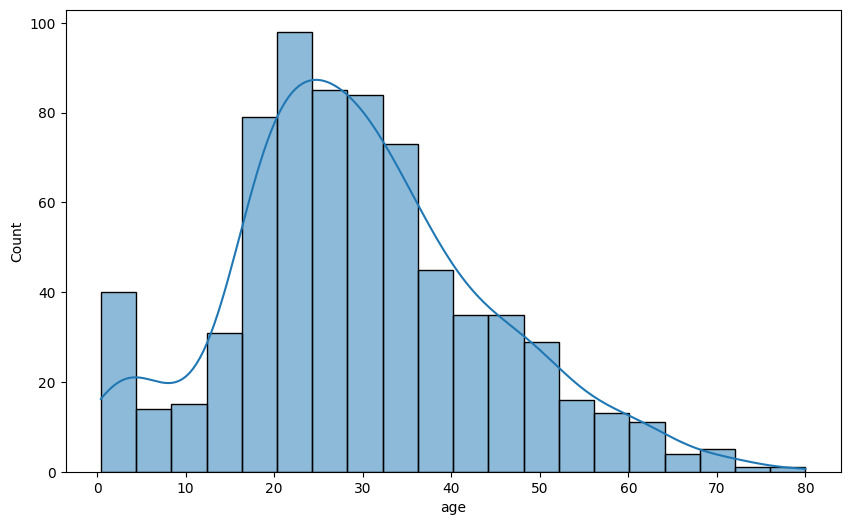

```python
plt.figure(figsize=(10,6))
sns.histplot(titanic_data_encoded.age,kde=True)
```

#### Initial information about the age column

1. The mean value is 29.6999118
2. The standard deviation is 14.526497
3. The min and max age in years are 0.42 and 80 respectively

```python
titanic_data_encoded['age'].describe()
```

```
count    714.000000
mean      29.699118
std       14.526497
min        0.420000
25%       20.125000
50%       28.000000
75%       38.000000
max       80.000000
Name: age, dtype: float64
```

```python
titanic_data_encoded_mean_method=titanic_data_encoded.copy()
titanic_data_encoded_mean_method['age']=titanic_data_encoded_mean_method['age'].fillna(titanic_data_encoded_mean_method['age'].mean())
titanic_data_encoded_mean_method.head(n=7)
```

|  | survived | pclass | age | sibsp | parch | fare | embarked_Q | embarked_S | embark_town_Queenstown | embark_town_Southampton | ... | adult_male_True | alone_True | deck_A | deck_B | deck_C | deck_D | deck_E | deck_F | deck_G | deck_nan |
| --- | --- | --- | --- | --- | --- | --- | --- | --- | --- | --- | --- | --- | --- | --- | --- | --- | --- | --- | --- | --- | --- |
| 0 | 0 | 3 | 22.000000 | 1 | 0 | 7.2500 | 0 | 1 | 0 | 1 | ... | 1 | 0 | 0 | 0 | 0 | 0 | 0 | 0 | 0 | 1 |
| 1 | 1 | 1 | 38.000000 | 1 | 0 | 71.2833 | 0 | 0 | 0 | 0 | ... | 0 | 0 | 0 | 0 | 1 | 0 | 0 | 0 | 0 | 0 |
| 2 | 1 | 3 | 26.000000 | 0 | 0 | 7.9250 | 0 | 1 | 0 | 1 | ... | 0 | 1 | 0 | 0 | 0 | 0 | 0 | 0 | 0 | 1 |
| 3 | 1 | 1 | 35.000000 | 1 | 0 | 53.1000 | 0 | 1 | 0 | 1 | ... | 0 | 0 | 0 | 0 | 1 | 0 | 0 | 0 | 0 | 0 |
| 4 | 0 | 3 | 35.000000 | 0 | 0 | 8.0500 | 0 | 1 | 0 | 1 | ... | 1 | 1 | 0 | 0 | 0 | 0 | 0 | 0 | 0 | 1 |
| 5 | 0 | 3 | 29.699118 | 0 | 0 | 8.4583 | 1 | 0 | 1 | 0 | ... | 1 | 1 | 0 | 0 | 0 | 0 | 0 | 0 | 0 | 1 |
| 6 | 0 | 1 | 54.000000 | 0 | 0 | 51.8625 | 0 | 1 | 0 | 1 | ... | 1 | 1 | 0 | 0 | 0 | 0 | 1 | 0 | 0 | 0 |

7 rows × 27 columns

#### Information about the age column after filling with the mean

1. The mean is 29.6999118
2. The standard deviation is 13.002015
3. The min and max age remains 0.420000 and 80.000000 respectively

```python
titanic_data_encoded_mean_method['age'].describe()
```

```
count    891.000000
mean      29.699118
std       13.002015
min        0.420000
25%       22.000000
50%       29.699118
75%       35.000000
max       80.000000
Name: age, dtype: float64
```

#### visualize the age column distibution after filling with the mean

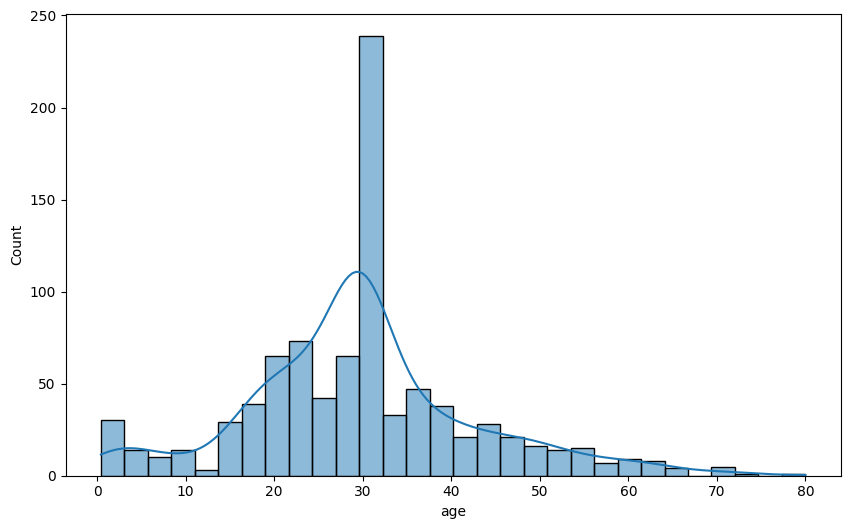

```python
plt.figure(figsize=(10,6))
sns.histplot(titanic_data_encoded_mean_method.age,kde=True)
```

#### Option 2: Using K-Nearest Neighbors (KNN) Imputation and check distribution again

```python
titanic_data_encoded_knn_method=titanic_data_encoded.copy()
knn_imputer=KNNImputer(n_neighbors=5)
titanic_data_encoded_knn_method['age']=knn_imputer.fit_transform(titanic_data_encoded_knn_method[['age']])
titanic_data_encoded_knn_method['age'].describe()
```

```
count    891.000000
mean      29.699118
std       13.002015
min        0.420000
25%       22.000000
50%       29.699118
75%       35.000000
max       80.000000
Name: age, dtype: float64
```

#### Information about the age column after using the knn method

1. The mean is 29.6999118
2. The standard deviation is 13.002015
3. The min and max age remains 0.420000 and 80.000000 respectively

#### Visualizing the distribution after using knn method

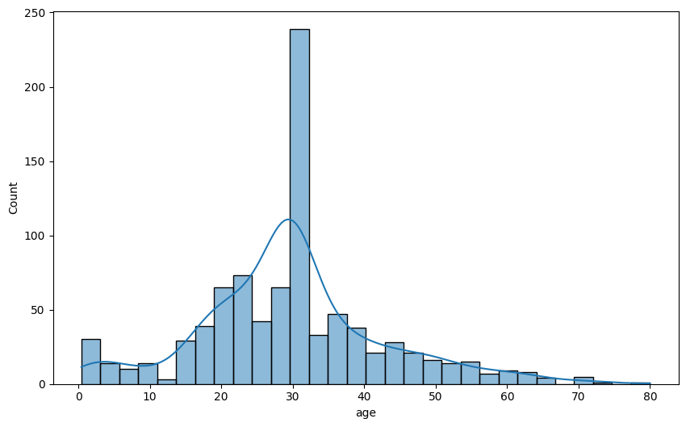

```python
plt.figure(figsize=(10,6))
sns.histplot(titanic_data_encoded_knn_method.age,kde=True)
```

### Making a Choice between the two options

#### Obviously the choice between the mean and knn method is one of such rare opportunity of choosing between two good options , hence for no obvious reasons, I will utilize the knn method ,while noting the fact though that both options are good

### Standardization

1. It helps centers the data to have a mean of 0
2. It also scales the data to have a stabdard_deviation of 1

```python
titanic_data_encoded_knn_method_standardize=titanic_data_encoded_knn_method.copy()
numeric_columns=['age','fare']
scaler=StandardScaler()
titanic_data_encoded_knn_method_standardize[numeric_columns]=scaler.fit_transform(titanic_data_encoded_knn_method_standardize[numeric_columns])
titanic_data_encoded_knn_method_standardize.head(n=7)
```

|  | survived | pclass | age | sibsp | parch | fare | embarked_Q | embarked_S | embark_town_Queenstown | embark_town_Southampton | ... | adult_male_True | alone_True | deck_A | deck_B | deck_C | deck_D | deck_E | deck_F | deck_G | deck_nan |
| --- | --- | --- | --- | --- | --- | --- | --- | --- | --- | --- | --- | --- | --- | --- | --- | --- | --- | --- | --- | --- | --- |
| 0 | 0 | 3 | -0.592481 | 1 | 0 | -0.502445 | 0 | 1 | 0 | 1 | ... | 1 | 0 | 0 | 0 | 0 | 0 | 0 | 0 | 0 | 1 |
| 1 | 1 | 1 | 0.638789 | 1 | 0 | 0.786845 | 0 | 0 | 0 | 0 | ... | 0 | 0 | 0 | 0 | 1 | 0 | 0 | 0 | 0 | 0 |
| 2 | 1 | 3 | -0.284663 | 0 | 0 | -0.488854 | 0 | 1 | 0 | 1 | ... | 0 | 1 | 0 | 0 | 0 | 0 | 0 | 0 | 0 | 1 |
| 3 | 1 | 1 | 0.407926 | 1 | 0 | 0.420730 | 0 | 1 | 0 | 1 | ... | 0 | 0 | 0 | 0 | 1 | 0 | 0 | 0 | 0 | 0 |
| 4 | 0 | 3 | 0.407926 | 0 | 0 | -0.486337 | 0 | 1 | 0 | 1 | ... | 1 | 1 | 0 | 0 | 0 | 0 | 0 | 0 | 0 | 1 |
| 5 | 0 | 3 | 0.000000 | 0 | 0 | -0.478116 | 1 | 0 | 1 | 0 | ... | 1 | 1 | 0 | 0 | 0 | 0 | 0 | 0 | 0 | 1 |
| 6 | 0 | 1 | 1.870059 | 0 | 0 | 0.395814 | 0 | 1 | 0 | 1 | ... | 1 | 1 | 0 | 0 | 0 | 0 | 1 | 0 | 0 | 0 |

7 rows × 27 columns

### Compare distribution of age before and after standardization

### Distribution before the standardization for the age column

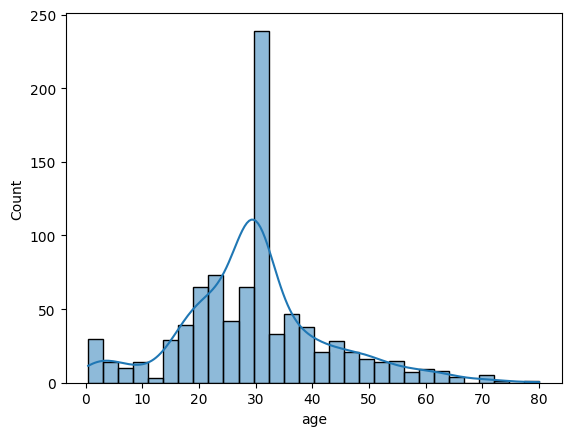

```python
sns.histplot(titanic_data_encoded_knn_method.age,kde=True)
```

### Distribution of the data after standardization for the age column

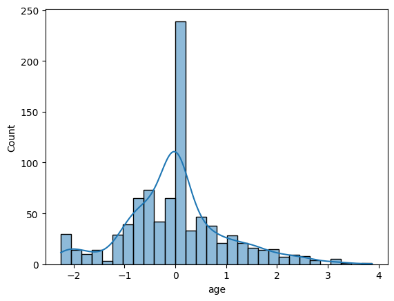

```python
sns.histplot(titanic_data_encoded_knn_method_standardize.age,kde=True)
```

### Distribution of the fare data just before the standardization

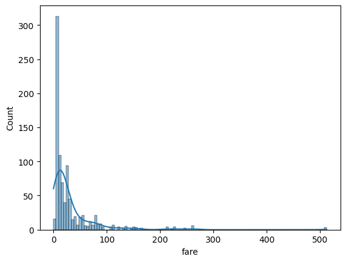

```python
sns.histplot(titanic_data_encoded_knn_method.fare,kde=True)
```

### Distribution after the standardization has been made for the fare

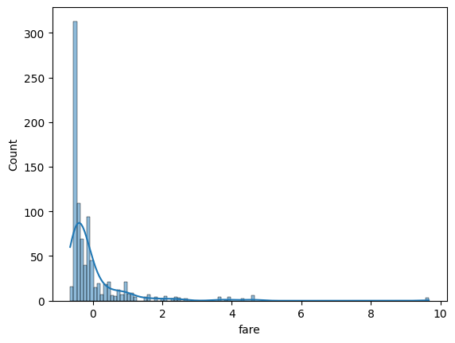

```python
sns.histplot(titanic_data_encoded_knn_method_standardize.fare,kde=True)
```

## Stage 7 : Handling Time Series Data

1. Extract relevant time based features
2. Resample or aggregate data based on time intervals

### NB : *Not Applicable to our Dataset*

## Stage 8: Handling Text Data

1. Tokenize and preprocess text data
2. Apply techniques like TF-IDF or word embeddings for feature representations

### NB : *Not Applicable to our Dataset*

## Stage 9 : Dealing with imbalanced data

1. Apply techniques like oversampling, undersampling, or using synthetic data to balance classes

## Stage 10 : Correlation

1. Correlation analysis is a valuable step in understanding the relationships within the data and making informed decisions during the feature selection process.
2. In the resulting heatmap, darker colors indicate stronger correlations.
3. The visualization helps to identify potential features for the mode based on their correlation with the target variable('survived') and to also detect multicollinearity among features.

```
Correlation with Target Variable (survived):
survived                   1.000000
pclass                    -0.338481
age                       -0.069809
sibsp                     -0.035322
parch                      0.081629
fare                       0.257307
embarked_Q                 0.003650
embarked_S                -0.155660
embark_town_Queenstown     0.003650
embark_town_Southampton   -0.155660
alive_yes                  1.000000
sex_male                  -0.543351
who_man                   -0.557080
who_woman                  0.506562
class_Second               0.093349
class_Third               -0.322308
adult_male_True           -0.557080
alone_True                -0.203367
deck_A                     0.022287
deck_B                     0.175095
deck_C                     0.114652
deck_D                     0.150716
deck_E                     0.145321
deck_F                     0.057935
deck_G                     0.016040
deck_nan                  -0.319572
dtype: float64
```

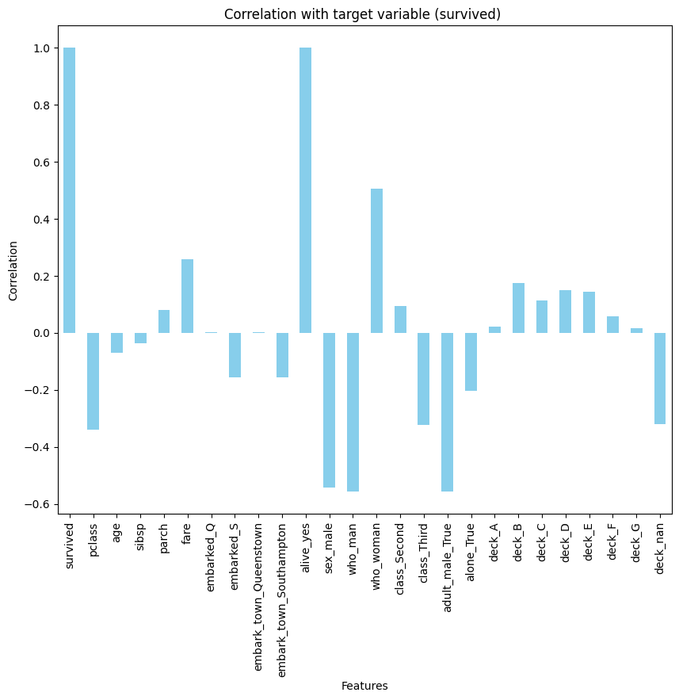

```python
target_variable='survived'

titanic_data_encoded_knn_method_standardize=titanic_data_encoded_knn_method_standardize.loc[:,~titanic_data_encoded_knn_method_standardize.columns.duplicated()]

### Calculating correlation between features and the target variable
correlation_with_target=titanic_data_encoded_knn_method_standardize.corrwith(titanic_data_encoded_knn_method_standardize[target_variable])

#Display the correlation with the target variable
print("Correlation with Target Variable ({}): \n{}".format(target_variable,correlation_with_target))

#Visualize the relationship with the target variable
plt.figure(figsize=(10,8))
correlation_with_target.plot(kind='bar',color='skyblue')
plt.title('Correlation with target variable ({}) '.format(target_variable))
plt.xlabel('Features')
plt.ylabel('Correlation')
plt.show()
```

#### Correlation between each feature and the target variable

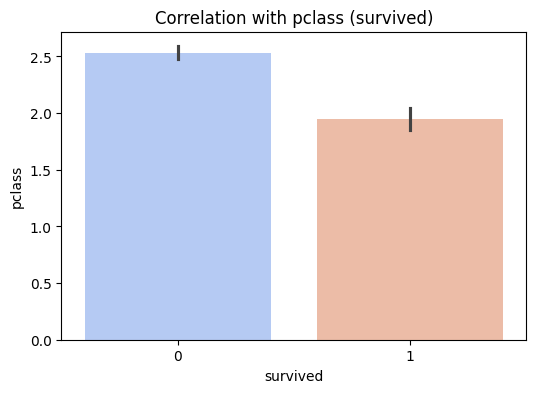

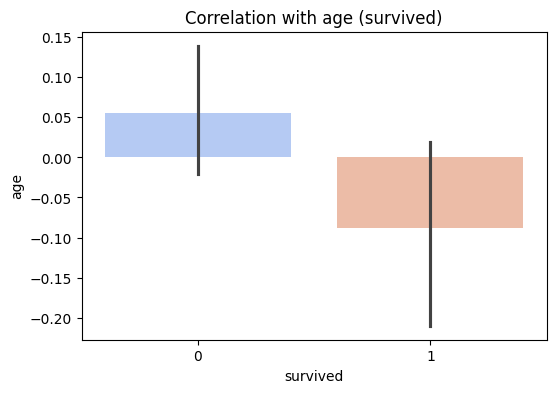

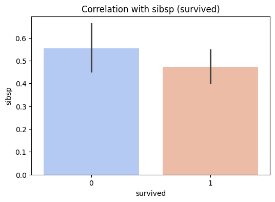

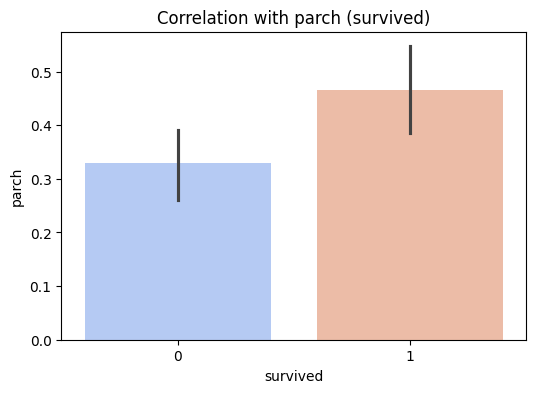

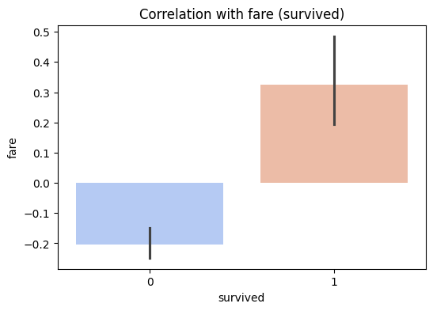

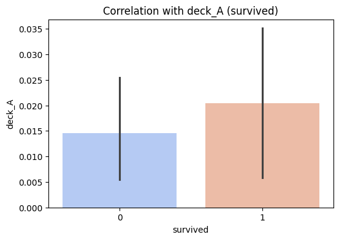

```python
target_variable='survived'
correlation_with_target=titanic_data_encoded_knn_method_standardize.corrwith(titanic_data_encoded_knn_method_standardize[target_variable])

selected_features=['pclass','age','sibsp','parch','fare','deck_A']
#Iterating through the selected features and visualizing the correlation with the target variable
for feature in selected_features:
    ### Calculate correlation with the target variable
    correlation_with_target=titanic_data_encoded_knn_method_standardize[feature].corr(titanic_data_encoded_knn_method_standardize[target_variable])

    #Visualize the correlation
    plt.figure(figsize=(6,4))
    sns.barplot(x=titanic_data_encoded_knn_method_standardize[target_variable],y=titanic_data_encoded_knn_method_standardize[feature],palette='coolwarm')
    plt.title('Correlation with {} ({})'.format(feature,target_variable))
    plt.xlabel(target_variable)
    plt.ylabel(feature)
    plt.show()
```

#### These visualizations provide insights into the relationships between the selected features and the target variable

### Correlation Interpretation

1. Features with high positive or negative correlation (close to 1 or -1) mean they move in the same direction. It would be considered to remove one of such to avoid multicollinearity
2. Features with low correlation to the target variable or other features may not provide much information , they may be removed after using domain knowledge to validate their importance
3. Correlation with the target variable that are low are likely candidates for removal

### In view of this, with a benchmark of 0.01, the following have a positive correlation likely to be considered with the target variable

##### parch(0.08) fare(0.25) alive_yes(1.0) who_woman(0.50),class_second(0.09),deck_A(0.02),deck_C(0.11),deck_B(0.17),deck_F(0.05),deck_G(0.02)

##### Moreso, some of the variables have some strong correlation with one another , in this case, just one may be picked to avoid affecting the model due to the collinearity

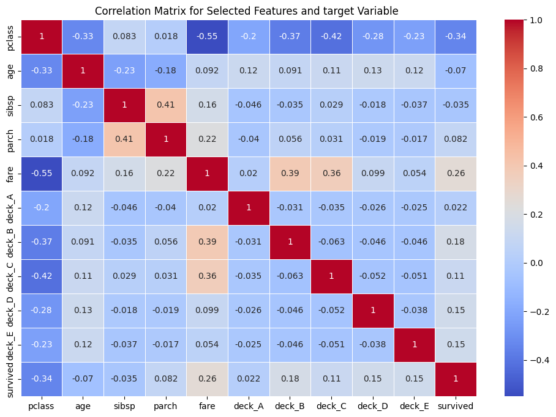

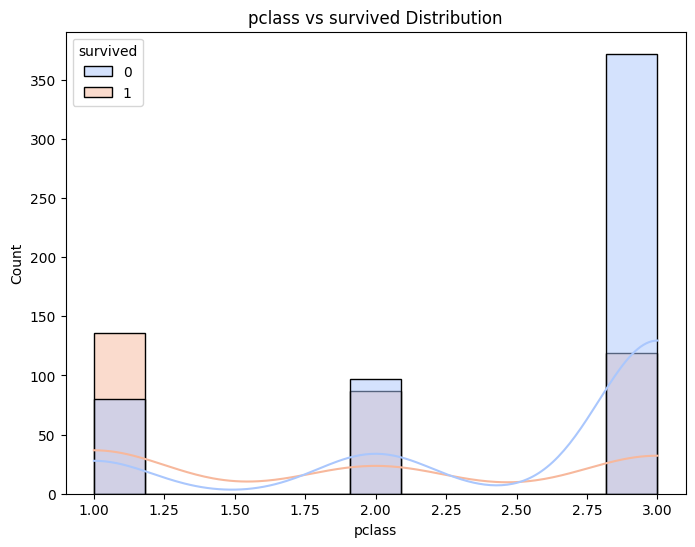

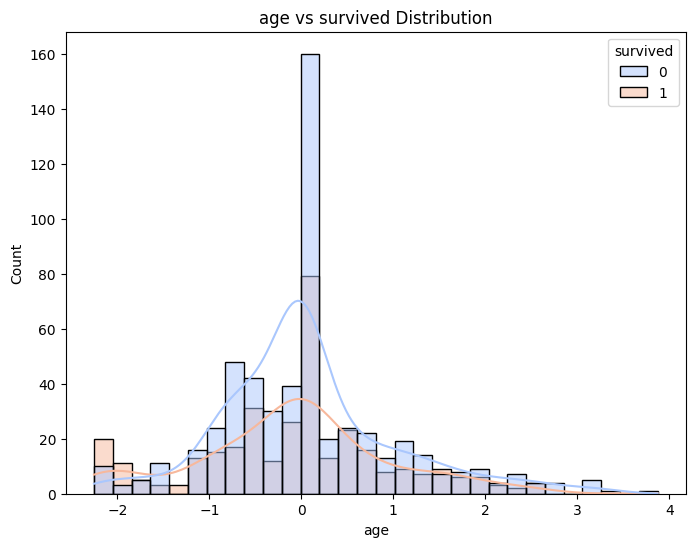

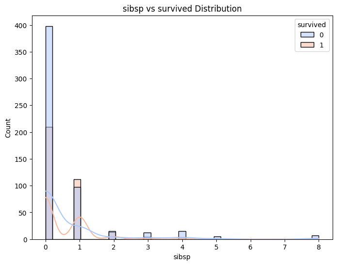

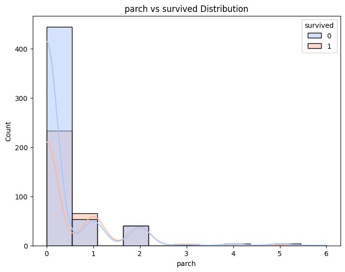

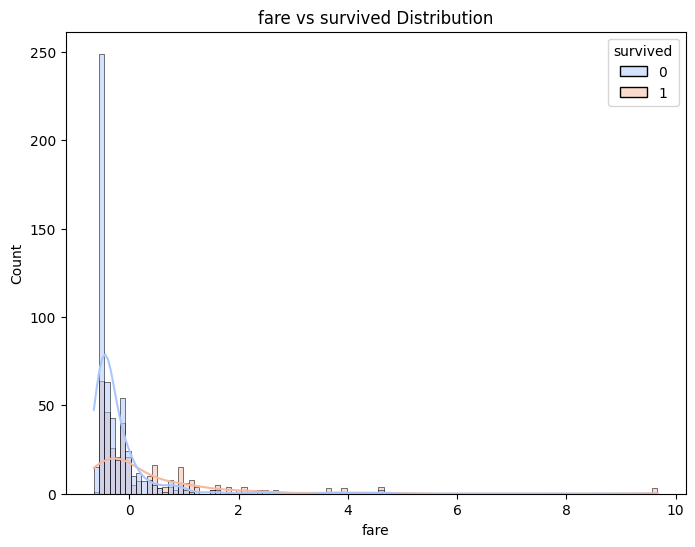

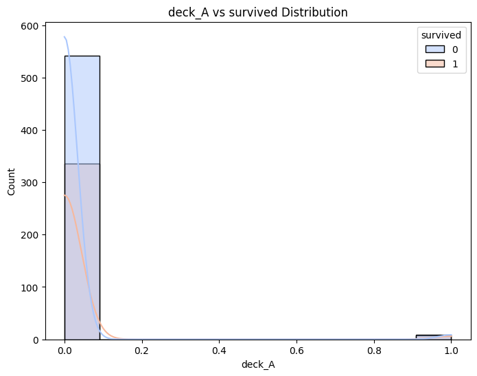

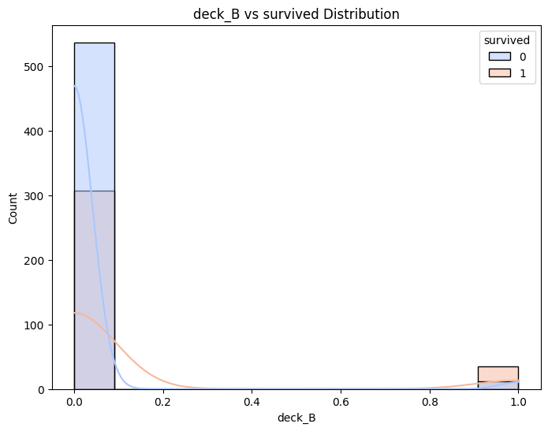

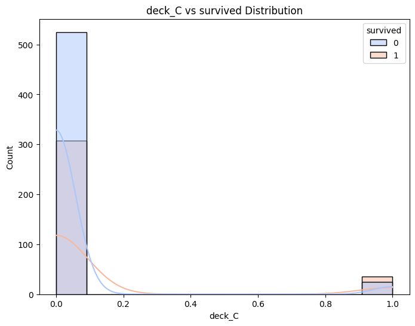

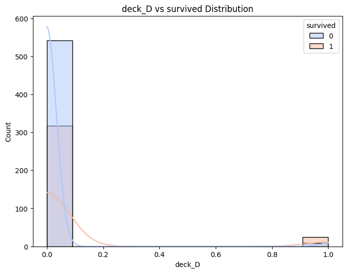

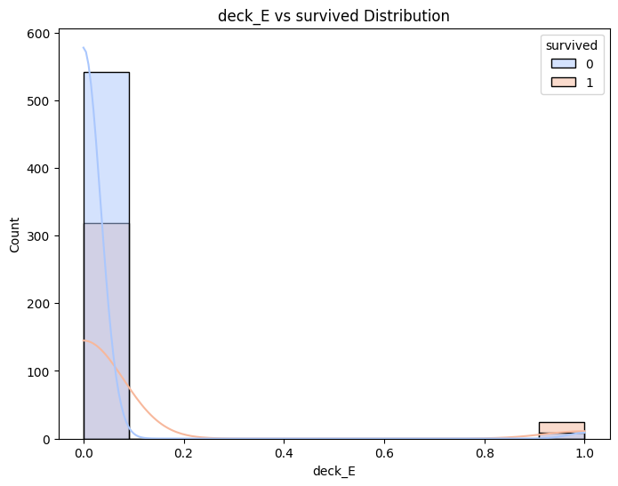

```python
target_variable='survived'
selected_features=['pclass','age','sibsp','parch','fare','deck_A','deck_B','deck_C','deck_D','deck_E']

#Calculate correlation matrix for the selected features and the target variable
subset_corr_matrix=titanic_data_encoded_knn_method_standardize[selected_features + [target_variable]].corr()

#Visualize the correlation matrix as a heatmap
plt.figure(figsize=(12,8))
sns.heatmap(subset_corr_matrix,annot=True,cmap='coolwarm',linewidths=.5)
plt.title('Correlation Matrix for Selected Features and target Variable ')
plt.show()

#Visualize the relationship between selected features and the target variable
for feature in selected_features:
    plt.figure(figsize=(8,6))

    if titanic_data_encoded_knn_method_standardize[feature].dtype=='0':
        sns.countplot(x=feature,hue=target_variable,data=titanic_data_encoded_knn_method_standardize,palette='coolwarm')
    else: #Numeric feature
        sns.histplot(x=titanic_data_encoded_knn_method_standardize[feature],hue=titanic_data_encoded_knn_method_standardize[target_variable],kde=True,palette='coolwarm')

    plt.title('{} vs {} Distribution'.format(feature,target_variable))
    plt.xlabel(feature)
    plt.ylabel('Count')
    plt.show()
```

## Process utilized in feature selection

### 1. Domain Knowledge Consideration

#### Relecting on the domain knowledge to identify features that are likely to have a significant impact on the target variable. Some features may be crucial for decision-making even if their correlation is not very high

#### Some of those features I consider when it comes to domain knowledge are :

1. PClass : Ticket class could be indicative of socio-economic status
2. Sex: Gender might influence survial rates
3. Sibsp and Parch: Family size might affect survival rates
4. Embarked: Port of embarkation might be correlated with socio-economic status
5. Fare: The amount paid might reflect socio-economic status

### 2. Exploring Feature Importance

#### This involves use if feature importance techniques, especially if you plan to use tree-based models like Random Forest. We train a model and examine the importance scores assigned to each feature.

##### Separate the features from the target variable

```python
X=titanic_data_encoded_knn_method_standardize.drop(columns=['survived'])

duplicated_columns=X.columns[X.columns.duplicated()]
duplicated_columns
X=X.loc[:,~X.columns.duplicated()]
y=titanic_data_encoded_knn_method_standardize['survived']
```

##### Train a Random Forest Classifier

```python
rf_classifier=RandomForestClassifier(n_estimators=100,random_state=42)
rf_classifier.fit(X,y)
```

```
RandomForestClassifier(random_state=42)
```

##### Plot feature importance

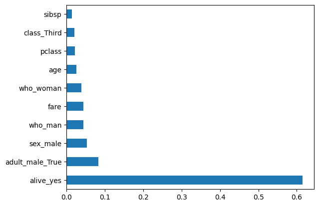

```python
feature_importance=pd.Series(rf_classifier.feature_importances_,index=X.columns)
feature_importance.nlargest(10).plot(kind='barh')
plt.show()
```

#### From the feature importance, we can see the following features were selected for viz: alive_yes,who_man,adult_male_true,sex_male,who_woman,fare,pclass,class_Third,age

## 3. Using Statistical tests

### This can involve use of chi-squared tests for categorical variables or t-tests for continuous variables can help identify features with a significant impact on the target variable

## 4. Regularization Techniques

### For the purpose of applying linear models, we can can consider applying regularization techniques like Lasso or Ridge regression.

### These methods penalize or exclude less importance features based on their coefficients

#### Using Ridge for feature selection

```python
X=titanic_data_encoded_knn_method_standardize.drop(columns=['survived'])
y=titanic_data_encoded_knn_method_standardize['survived']
ridge_model=Ridge(alpha=0.9,random_state=42)

#Selecting features based on ridge coefficients
sfm_ridge=SelectFromModel(ridge_model)
sfm_ridge.fit(X,y)

#Display selected features
selected_features_ridge=X.columns[sfm_ridge.get_support()]
print("Selected Features (Ridge): ",selected_features_ridge)
```

```
Selected Features (Ridge):  Index(['alive_yes'], dtype='object')
```

#### We also separate the features from the target variables

```python
X=titanic_data_encoded_knn_method_standardize.drop(columns=['survived'])
y=titanic_data_encoded_knn_method_standardize['survived']
```

#### Select features based on Lasso coefficients

```python
lasso_model=Lasso(alpha=0.1,random_state=42)
sfm_lasso=SelectFromModel(lasso_model)
sfm_lasso.fit(X,y)
```

```
SelectFromModel(estimator=Lasso(alpha=0.1, random_state=42))
```

#### Display selected features from the lasso coefficients

```python
selected_features_lasso=X.columns[sfm_lasso.get_support()]
print("Selected features (Applying Lasso): \n",selected_features_lasso)
```

```
Selected features (Applying Lasso):
 Index(['alive_yes'], dtype='object')
```

## 5. Iterative Testing

### This involves testing different feature sets iteratively, train the models , and evaluate their performance using cross-validation or a separate validation set. Here I would apply some feature iteratively just as stated

### Recursive Feature Elimination (RFE)

```python
X=titanic_data_encoded_knn_method_standardize.drop(columns=['survived'])
y=titanic_data_encoded_knn_method_standardize['survived']

model=LogisticRegression()
rfe=RFE(model,n_features_to_select=5)
fit=rfe.fit(X,y)
selected_features=X.columns[fit.support_]
print("Selected features with RFE: ",selected_features)
```

```
Selected features with RFE:  Index(['pclass', 'alive_yes', 'sex_male', 'who_man', 'adult_male_True'], dtype='object')
```

### Tree-based methods (Random Forest)

```python
X=titanic_data_encoded_knn_method_standardize.drop(columns=['survived'])
y=titanic_data_encoded_knn_method_standardize['survived']
model=RandomForestClassifier()
model.fit(X,y)
feature_importances=model.feature_importances_
selected_features=X.columns[np.argsort(feature_importances)[::-1][:5]]
print("Selected Features with RandomForest Tree based method \n")
print(selected_features)
```

```
Selected Features with RandomForest Tree based method

Index(['alive_yes', 'adult_male_True', 'who_man', 'sex_male', 'fare'], dtype='object')
```

### LASSO Regression

```python
X=titanic_data_encoded_knn_method_standardize.drop(columns=['survived'])
y=titanic_data_encoded_knn_method_standardize['survived']
model=Lasso(alpha=0.01)
model.fit(X,y)
selected_features=X.columns[model.coef_ != 0]
print("selected features with LASSO Regression are: \n")
print(selected_features)
```

```
selected features with LASSO Regression are:

Index(['alive_yes'], dtype='object')
```

### Univariate Feature Selection

```python
X=titanic_data_encoded_knn_method_standardize.drop(columns=['survived'])
y=titanic_data_encoded_knn_method_standardize['survived']
X_new=X.columns[SelectKBest(f_classif,k=5).fit(X,y).get_support()]
print("Features selected with Univariate feature selection is/ are : \n")
print(X_new)
```

```
Features selected with Univariate feature selection is/ are :

Index(['alive_yes', 'sex_male', 'who_man', 'who_woman', 'adult_male_True'], dtype='object')
```

### Mutual Information

```python
X=titanic_data_encoded_knn_method_standardize.drop(columns=['survived'])
y=titanic_data_encoded_knn_method_standardize['survived']
mi_scores=mutual_info_classif(X,y)
selected_features=X.columns[mi_scores.argsort()[-5:][::-1]]
print("Selected features with mutual information \n")
print(selected_features)
```

```
Selected features with mutual information

Index(['alive_yes', 'who_man', 'sex_male', 'adult_male_True', 'who_woman'], dtype='object')
```

### Brief Report :

### It appears that after combininng the various process of feature selection with domain knowledge, we can safely pick the following features in order to proceed to our model evaluation

### Features include : *alive_yes,who_man,sex_male,adult_male_True,who_woman,fare,class_Third,pclass,age and sibsp*

## 6. Model Evaluation

### This involves evaluation of the performance of the machine learning models with different feature sets using appropriate metrics (eg. accuracy,precision,recall,F1-score). This helps to understand how the models generalize to new set of data

### *NB:* The alive_yes was removed due to its unncessarily high correlation which caused the models to be overfitting and giving an arguable accuracy of 100%

### Improvements on the codes helped resolved the issue and these are how its done :

#### 1. Data Leakage: Check that there are no data leakage , where information from the test set is unintentionally used during the training , hence ensure independence

#### 2. Accuracy may not always be the best metric , especially in imbalanced datasets. hence you consider using other metrics like precision,recall,F1-score, or area under the curve (AUC-ROC) for a more comprehensive evaluation

#### 3. Cross validation: Implement cross validation to get a better estimate of your model's performance . It helps to detect if the model is sensitive to a particular subset of the datav

#### 4. Feature Importance Analysis : Examine the feature importances if you're using a model like Random Forest. It might help you understand if certain features dominate the prediction process. eg You may observe at some point, I removed the alive_yes column

#### 5. Model complexity : Consider reducing the complexity of your model. Simplify the model architecture or use techniques like regularization to prevent ovefitting

#### Separating the features into features(represented as A) and target(represented as b)

```python
selected_feature_names=['who_man','sex_male','adult_male_True','who_woman','fare','class_Third','pclass','age','sibsp']
selected_data=titanic_data_encoded_knn_method_standardize[selected_feature_names +['survived']]
selected_data.head(n=7)
```

|  | who_man | sex_male | adult_male_True | who_woman | fare | class_Third | pclass | age | sibsp | survived |
| --- | --- | --- | --- | --- | --- | --- | --- | --- | --- | --- |
| 0 | 1 | 1 | 1 | 0 | -0.502445 | 1 | 3 | -0.592481 | 1 | 0 |
| 1 | 0 | 0 | 0 | 1 | 0.786845 | 0 | 1 | 0.638789 | 1 | 1 |
| 2 | 0 | 0 | 0 | 1 | -0.488854 | 1 | 3 | -0.284663 | 0 | 1 |
| 3 | 0 | 0 | 0 | 1 | 0.420730 | 0 | 1 | 0.407926 | 1 | 1 |
| 4 | 1 | 1 | 1 | 0 | -0.486337 | 1 | 3 | 0.407926 | 0 | 0 |
| 5 | 1 | 1 | 1 | 0 | -0.478116 | 1 | 3 | 0.000000 | 0 | 0 |
| 6 | 1 | 1 | 1 | 0 | 0.395814 | 0 | 1 | 1.870059 | 0 | 0 |

#### Separating the data into features and the main target

```python
A=selected_data.drop('survived',axis=1)
b=selected_data['survived']
```

#### Train-Test split of the data

```python
A_train,A_test,b_train,b_test=train_test_split(A,b,test_size=0.2) #meaning we have a test size of 20% of the original data
```

### Applying Clasffication Models

#### Model 1: Random Forest Classifier

```python
model=RandomForestClassifier()
model.fit(A_train,b_train)
```

```
RandomForestClassifier()
```

#### Predictions & Evaluation metrics

```python
predictions=model.predict(A_test)
accuracy=accuracy_score(b_test,predictions) *100
report=classification_report(b_test,predictions)
model_lr=LogisticRegression()
cross_val_scores=cross_val_score(model_lr,A,b,cv=5) # You can adjust the number of folds as needed
average_cross_val_score=cross_val_scores.mean() *100

print(f"Accuracy of RandomForestClassifier Model is : {accuracy:.2f}%")
print(f"Classification Report : \n {report}")
print(f"\n Average Cross-Validation Accuracy {average_cross_val_score:.2f}%")
```

```
Accuracy of RandomForestClassifier Model is : 86.03%
Classification Report :
               precision    recall  f1-score   support

           0       0.87      0.91      0.89       112
           1       0.84      0.78      0.81        67

    accuracy                           0.86       179
   macro avg       0.86      0.84      0.85       179
weighted avg       0.86      0.86      0.86       179


 Average Cross-Validation Accuracy 81.37%
```

#### Comprehensive Evaluation from with Logistic Regression and Support Vector Machines

#### Python Function to display results

```python
def display_results(model_name,predictions,b_test):
    accuracy=accuracy_score(b_test,predictions)*100
    report=classification_report(b_test,predictions)

    print(f"{model_name} Results: ")
    print(f"Accuracy: {accuracy:.2f}%")
    print(f"Classification Report : \n{report}\n")
```

#### Logistic Regression with Python display function

```python
model_lr=LogisticRegression()
model_lr.fit(A_train,b_train)
predictions_lr=model_lr.predict(A_test)
display_results("Logistic Regression",predictions_lr,b_test)
```

```
Logistic Regression Results:
Accuracy: 81.56%
Classification Report :
              precision    recall  f1-score   support

           0       0.84      0.87      0.85       112
           1       0.77      0.73      0.75        67

    accuracy                           0.82       179
   macro avg       0.80      0.80      0.80       179
weighted avg       0.81      0.82      0.81       179
```

#### Support Vector Machine with Python display function

```python
model_svm=SVC()
model_svm.fit(A_train,b_train)
predictions_svm=model_svm.predict(A_test)
display_results("Support Vector Machine",predictions_svm,b_test)
```

```
Support Vector Machine Results:
Accuracy: 82.12%
Classification Report :
              precision    recall  f1-score   support

           0       0.84      0.88      0.86       112
           1       0.78      0.73      0.75        67

    accuracy                           0.82       179
   macro avg       0.81      0.80      0.81       179
weighted avg       0.82      0.82      0.82       179
```

#### Random Forest model with the Python display function

```python
model_rf=RandomForestClassifier()
model_rf.fit(A_train,b_train)
predictions_rf=model_rf.predict(A_test)
display_results("Random Forest",predictions_rf,b_test)
```

```
Random Forest Results:
Accuracy: 85.47%
Classification Report :
              precision    recall  f1-score   support

           0       0.87      0.90      0.89       112
           1       0.83      0.78      0.80        67

    accuracy                           0.85       179
   macro avg       0.85      0.84      0.84       179
weighted avg       0.85      0.85      0.85       179
```

#### K-Nearest Neighbors (KNN) with the python display function

```python
model_knn=KNeighborsClassifier()
model_knn.fit(A_train,b_train)
predictions_knn=model_knn.predict(A_test)
display_results("K-Nearest Neighbors",predictions_knn,b_test)
```

```
K-Nearest Neighbors Results:
Accuracy: 83.24%
Classification Report :
              precision    recall  f1-score   support

           0       0.87      0.87      0.87       112
           1       0.78      0.78      0.78        67

    accuracy                           0.83       179
   macro avg       0.82      0.82      0.82       179
weighted avg       0.83      0.83      0.83       179
```

#### Decision Tree with the python display function

```python
model_dt=DecisionTreeClassifier()
model_dt.fit(A_train,b_train)
predictions_dt=model_dt.predict(A_test)
display_results("Decision Tree",predictions_dt,b_test)
```

```
Decision Tree Results:
Accuracy: 81.01%
Classification Report :
              precision    recall  f1-score   support

           0       0.83      0.88      0.85       112
           1       0.77      0.70      0.73        67

    accuracy                           0.81       179
   macro avg       0.80      0.79      0.79       179
weighted avg       0.81      0.81      0.81       179
```

#### Formula: TP/(FP + FN)

#### Meaning: Recall measures the ability of the model to capture all positive instances. It answers the question: of all positive instances , how many were predicted as positive ? Higher recall means fewer false negatives

### 4. F1-Score (Precision * Recall) /(Precision + Recall)

#### Meaning: F1-Score is the harmonic mean of precision and recall. It balances precision and recall, providing a single metric that considers both false positives and false negatives. it is especially useful when classes are imbalanced

### *In conclusion after this model evaluation stage , the next stages in the grand scheme of the Machine Learning workflow typically involve the following, (which I won't delve into) but provide brief explanation for learning purpose*

## Stage 7: *Model Tuning (Hyperparameter Optimization*

### This involves identifying the optimal hyperparameters for the chosen model. Using techniques which can involve grid search or random search to explore different combinations of hyperparameters and find the ones that maximize performance

## Stage 8: Revisiting Feature Engineering

### One may revisit additional feature engineering techniques.This could involve creating new features ,transforming existing ones, or encoding categorical variables in a more meaningdul way

## Stage 9: Revisiting Data Preprocessing and Model Deployment agiain.

## Stage 10 :Monitoring and Deployment

## Stage 11: Documentation

### Simply documenting the entire workflow, which I had paid great attention to right from the outset of the project ,This can enable others reproduce the work one has done

### *In Conclusion, Machine Learning lifecycle is not a linear path; It onvolves continuous learning and refinement. Each stage informs the others, and the process is often cyclical, with models being updated and improved over time*

### __** And I hope you can say I have done my due diligence as a wannabe Medic, taking you systemically through the whole process as if often required in critically diagnosing and treating a patient

### [My Personal Online Portfolio](https://chasfatprojects.netlify.app)

### [My Tiktok Page where I troubleshoot programming problems in my domain](https://www.tiktok.com/@chasfat)

### [My Twitter handle, you may follow me as a means to appreciate this project](https://www.twitter.com/@Chasfat_Project)